# CITS4009 Project 1 — Exploratory Data Analysis

Shuyu Xie

2023-08-26

# Introduction

Introduction: The advent of online video consumption has revolutionized content accessibility and engagement. YouTube, as a leading video-sharing platform, has achieved global prominence and garnered billions of users. It offers a wide array of content genres, ranging from entertainment to education and marketing. Understanding the trends and patterns within YouTube’s ecosystem is essential for content creators, marketers, and researchers. This report aims to explore the [“Global YouTube Statistics 2023”](https://www.kaggle.com/datasets/nelgiriyewithana/global-youtube-statistics-2023) dataset available on Kaggle. This comprehensive dataset presents a holistic view of YouTube’s global performance, including metrics such as video views, subscriber counts, channel categories, and regional statistics. By analyzing this dataset, we seek to unearth insights into the current YouTube landscape and uncover trends to drive strategic decision-making and content creation.

# Data

## Overview

The [“Global YouTube Statistics 2023”](https://www.kaggle.com/datasets/nelgiriyewithana/global-youtube-statistics-2023) dataset encompasses a wide range of metrics that encapsulate the dynamic nature of the platform. It reflects user preferences and behaviors across various countries and regions globally. By examining these statistics, we can identify popular content genres, assess the impact of regional factors on viewership, and analyze YouTube channel growth patterns.

```r
library(tidyverse)
library(patchwork)
library(leaflet)
library(DT)
library(lubridate)
library(GGally)

Sys.setlocale(local = "EN")
```

```
[1] "LC_COLLATE=EN;LC_CTYPE=EN;LC_MONETARY=EN;LC_NUMERIC=C;LC_TIME=EN"
```

```r
DataRaw <- read.csv('./Global YouTube Statistics.csv')
```

Through Kaggle’s dataset description, the meanings of different variables are:

| Column Name | Meaning | Variable Type |
| --- | --- | --- |
| rank | Position of the YouTube channel based on subscribers | Numeric |
| Youtuber | Name of the YouTube channel | Character |
| subscribers | Number of subscribers to the channel | Numeric |
| video views | Total views across all videos on the channel | Numeric |
| category | Category or niche of the channel | Character |
| Title | Title of the YouTube channel | Character |
| uploads | Total number of videos uploaded on the channel | Numeric |
| Country | Country where the YouTube channel originates | Character |
| Abbreviation | Abbreviation of the country | Character |
| channel_type | Type of the YouTube channel (e.g., individual, brand) | Character |
| video_views_rank | Ranking of the channel based on total video views | Numeric |
| country_rank | Ranking of the channel based on subscribers within its country | Numeric |
| channel_type_rank | Ranking of the channel based on its type (individual or brand) | Numeric |
| video_views_for_the_last_30_days | Total video views in the last 30 days | Numeric |
| lowest_monthly_earnings | Lowest estimated monthly earnings from the channel | Numeric |
| highest_monthly_earnings | Highest estimated monthly earnings from the channel | Numeric |
| lowest_yearly_earnings | Lowest estimated yearly earnings from the channel | Numeric |
| highest_yearly_earnings | Highest estimated yearly earnings from the channel | Numeric |
| subscribers_for_last_30_days | Number of new subscribers gained in the last 30 days | Numeric |
| created_year | Year when the YouTube channel was created | Numeric |
| created_month | Month when the YouTube channel was created | Numeric |
| created_date | Exact date of the YouTube channel’s creation | Numeric |
| Gross tertiary education enrollment (%) | Percentage of the population enrolled in tertiary education in the country | Numeric |
| Population | Total population of the country | Numeric |
| Unemployment rate | Unemployment rate in the country | Numeric |
| Urban_population | Percentage of the population living in urban areas | Numeric |
| Latitude | Latitude coordinate of the country’s location | Numeric |
| Longitude | Longitude coordinate of the country’s location | Numeric |

## Data Cleaning

In this report, we will begin by excluding certain insignificant variables, such as the “Title,” as it contains some garbled text that may pose challenges for subsequent analysis. Furthermore, for the column labeled “YouTuber” that contains special characters, we can employ regular expressions to cleanse the data, thus preventing the occurrence of any erroneous outcomes.

```r
DataClean <- DataRaw |>
  select(-Title) |>
  ## create date, format is 2023-Jan-1
  mutate(
    Youtuber = str_remove_all(Youtuber, "[^[:alnum:]]"),
    date = paste(created_year, created_month, created_date, sep = "-"),
    date = as.Date(date, format = "%Y-%b-%d")
  ) |>
  select(-c(created_year, created_month, created_date))
datatable(DataClean, width = "100%", options = list(scrollX = TRUE))
```

|  | rank | Youtuber | subscribers | video.views | category | uploads | Country | Abbreviation | channel_type | video_views_rank | country_rank | channel_type_rank | video_views_for_the_last_30_days | lowest_monthly_earnings | highest_monthly_earnings | lowest_yearly_earnings | highest_yearly_earnings | subscribers_for_last_30_days | Gross.tertiary.education.enrollment.... | Population | Unemployment.rate | Urban_population | Latitude | Longitude | date |
| --- | --- | --- | --- | --- | --- | --- | --- | --- | --- | --- | --- | --- | --- | --- | --- | --- | --- | --- | --- | --- | --- | --- | --- | --- | --- |
| 1 | 1 | TSeries | 245000000 | 228000000000 | Music | 20082 | India | IN | Music | 1 | 1 | 1 | 2258000000 | 564600 | 9000000 | 6800000 | 108400000 | 2000000 | 28.1 | 1366417754 | 5.36 | 471031528 | 20.593684 | 78.96288 | 2006-03-13 |
| 2 | 2 | YouTubeMovies | 170000000 | 0 | Film &amp; Animation | 1 | United States | US | Games | 4055159 | 7670 | 7423 | 12 | 0 | 0.05 | 0.04 | 0.58 |  | 88.2 | 328239523 | 14.7 | 270663028 | 37.09024 | -95.712891 | 2006-03-05 |
| 3 | 3 | MrBeast | 166000000 | 28368841870 | Entertainment | 741 | United States | US | Entertainment | 48 | 1 | 1 | 1348000000 | 337000 | 5400000 | 4000000 | 64700000 | 8000000 | 88.2 | 328239523 | 14.7 | 270663028 | 37.09024 | -95.712891 | 2012-02-20 |
| 4 | 4 | CocomelonNurseryRhymes | 162000000 | 164000000000 | Education | 966 | United States | US | Education | 2 | 2 | 1 | 1975000000 | 493800 | 7900000 | 5900000 | 94800000 | 1000000 | 88.2 | 328239523 | 14.7 | 270663028 | 37.09024 | -95.712891 | 2006-09-01 |
| 5 | 5 | SETIndia | 159000000 | 148000000000 | Shows | 116536 | India | IN | Entertainment | 3 | 2 | 2 | 1824000000 | 455900 | 7300000 | 5500000 | 87500000 | 1000000 | 28.1 | 1366417754 | 5.36 | 471031528 | 20.593684 | 78.96288 | 2006-09-20 |
| 6 | 6 | Music | 119000000 | 0 | nan | 0 | nan | nan | Music | 4057944 |  |  |  | 0 | 0 | 0 | 0 |  |  |  |  |  |  |  | 2013-09-24 |
| 7 | 7 | KidsDianaShow | 112000000 | 93247040539 | People &amp; Blogs | 1111 | United States | US | Entertainment | 5 | 3 | 3 | 731674000 | 182900 | 2900000 | 2200000 | 35100000 |  | 88.2 | 328239523 | 14.7 | 270663028 | 37.09024 | -95.712891 | 2015-05-12 |
| 8 | 8 | PewDiePie | 111000000 | 29058044447 | Gaming | 4716 | Japan | JP | Entertainment | 44 | 1 | 4 | 39184000 | 9800 | 156700 | 117600 | 1900000 |  | 63.2 | 126226568 | 2.29 | 115782416 | 36.204824 | 138.252924 | 2010-04-29 |
| 9 | 9 | LikeNastya | 106000000 | 90479060027 | People &amp; Blogs | 493 | Russia | RU | People | 630 | 5 | 25 | 48947000 | 12200 | 195800 | 146800 | 2300000 | 100000 | 81.9 | 144373535 | 4.59 | 107683889 | 61.52401 | 105.318756 | 2016-01-14 |
| 10 | 10 | VladandNiki | 98900000 | 77180169894 | Entertainment | 574 | United States | US | Entertainment | 8 | 5 | 6 | 580574000 | 145100 | 2300000 | 1700000 | 27900000 | 600000 | 88.2 | 328239523 | 14.7 | 270663028 | 37.09024 | -95.712891 | 2018-04-23 |

[output cut: 985 more lines]

I will utilize the `summary` and `table` functions to identify any anomalies or outliers within the table. Due to the lower likelihood of encountering outliers in the “Youtuber” column, and the potential difficulty in detecting them using the `summary` function, I will refrain from utilizing `summary` to examine its distribution.

```r
NameList <- names(DataClean[,-2])
name <- NameList[1]
for (name in NameList) {
  Col <- DataClean[,name]
  if(is.numeric(Col)|class(Col) == "Date"){
    print(name)
    print(summary(Col))
  } else {
    print(name)
    print(table(Col))
  }
}
```

```
[1] "rank"
   Min. 1st Qu.  Median    Mean 3rd Qu.    Max.
    1.0   249.5   498.0   498.0   746.5   995.0
[1] "subscribers"
     Min.   1st Qu.    Median      Mean   3rd Qu.      Max.
 12300000  14500000  17700000  22982412  24600000 245000000
[1] "video.views"
     Min.   1st Qu.    Median      Mean   3rd Qu.      Max.
0.000e+00 4.288e+09 7.761e+09 1.104e+10 1.355e+10 2.280e+11
[1] "category"
Col
     Autos & Vehicles                Comedy             Education         Entertainment
                    2                    69                    45                   241
     Film & Animation                Gaming         Howto & Style                Movies
                   46                    94                    40                     2
                Music                   nan       News & Politics Nonprofits & Activism
                  202                    46                    26                     2
       People & Blogs        Pets & Animals  Science & Technology                 Shows
                  132                     4                    17                    13
               Sports              Trailers       Travel & Events
                   11                     2                     1
[1] "uploads"
    Min.  1st Qu.   Median     Mean  3rd Qu.     Max.
     0.0    194.5    729.0   9187.1   2667.5 301308.0
[1] "Country"
Col
         Afghanistan              Andorra            Argentina            Australia           Bangladesh
                   1                    1                   13                    9                    1
            Barbados               Brazil               Canada                Chile                China
                   1                   62                   15                    3                    1
            Colombia                 Cuba              Ecuador                Egypt          El Salvador
                  11                    1                    2                    2                    1
             Finland               France              Germany                India            Indonesia
                   1                    5                    6                  168                   28
                Iraq                Italy                Japan               Jordan               Kuwait
                   2                    2                    5                    3                    1
              Latvia             Malaysia               Mexico              Morocco                  nan
                   1                    1                   33                    1                  122
         Netherlands             Pakistan                 Peru          Philippines               Russia
                   3                    6                    1                   12                   16
```

[output cut: 53 more lines]

```
[1] "Unemployment.rate"
   Min. 1st Qu.  Median    Mean 3rd Qu.    Max.    NA's
  0.750   5.270   9.365   9.279  14.700  14.720     123
[1] "Urban_population"
     Min.   1st Qu.    Median      Mean   3rd Qu.      Max.      NA's
    35588  55908316 270663028 224214982 270663028 842933962       123
[1] "Latitude"
   Min. 1st Qu.  Median    Mean 3rd Qu.    Max.    NA's
 -38.42   20.59   37.09   26.63   37.09   61.92     123
[1] "Longitude"
   Min. 1st Qu.  Median    Mean 3rd Qu.    Max.    NA's
-172.10  -95.71  -51.93  -14.13   78.96  138.25     123
[1] "date"
        Min.      1st Qu.       Median         Mean      3rd Qu.         Max.         NA's
"1970-01-01" "2009-09-16" "2013-06-05" "2013-02-14" "2016-06-05" "2022-06-27"          "5"
```

Indeed, upon further examination, we have identified an outlier in the date variable. There is one record with the date set as 1970-1-1, which precedes the founding of YouTube. This clearly appears to be an anomaly. Upon reviewing the data table, it is evident that the corresponding YouTuber for this observation is “YouTube” itself. Considering this, it is reasonable to treat this as a non-applicable (NA) value for the date. Therefore, I will replace it with NA.

```r
DataClean$date[DataClean$date == as.Date("1970-01-01")] <- NA
```

Within the character variables, the occurrence of the text “nan” should be replaced with “NA.” Similarly, in the numeric variables, the occurrence of “NAN” should be replaced with “NA.”

```r
name <- NameList[4]
for (name in NameList) {
  Col <- DataClean[,name]
  if(is.numeric(Col)|class(Col) == "Date"){
    DataClean[is.nan(DataClean[,name]),name] <- NA
  } else {
    DataClean[DataClean[,name] == "nan",name] <- NA
  }
}
```

Let’s add a new column that determines the count of missing values for each observation sample.

```r
DataClean <- DataClean |>
  mutate(
    na_count = rowSums(is.na(DataClean))
  )

table(DataClean$na_count)
```

```
  0   1   2   3   4   5   6   7   8   9  10  11  12  13  14
553 295  15   6   1   1   1   1   6  43  32  20  10   7   4
```

```r
round(100 *table(DataClean$na_count)/nrow(DataClean), 4)
```

```
      0       1       2       3       4       5       6       7       8       9      10      11      12
55.5779 29.6482  1.5075  0.6030  0.1005  0.1005  0.1005  0.1005  0.6030  4.3216  3.2161  2.0101  1.0050
     13      14
 0.7035  0.4020
```

Within this table, only 55.58% of the observations do not have any missing values. Out of these, there are 124 observations where six or more variables are missing.

```r
DataClean |>
  filter(na_count > 6) |>
  arrange(desc(na_count)) |>
  datatable(width = "100%", options = list(scrollX = TRUE))
```

|  | rank | Youtuber | subscribers | video.views | category | uploads | Country | Abbreviation | channel_type | video_views_rank | country_rank | channel_type_rank | video_views_for_the_last_30_days | lowest_monthly_earnings | highest_monthly_earnings | lowest_yearly_earnings | highest_yearly_earnings | subscribers_for_last_30_days | Gross.tertiary.education.enrollment.... | Population | Unemployment.rate | Urban_population | Latitude | Longitude | date | na_count |
| --- | --- | --- | --- | --- | --- | --- | --- | --- | --- | --- | --- | --- | --- | --- | --- | --- | --- | --- | --- | --- | --- | --- | --- | --- | --- | --- |
| 1 | 103 | News | 36300000 | 0 |  | 0 |  |  |  | 4057944 |  |  |  | 0 | 0 | 0 | 0 |  |  |  |  |  |  |  | 2013-09-09 | 14 |
| 2 | 237 | ChrisBrown | 25200000 | 15520569496 | Music | 0 |  |  |  | 3612215 |  |  |  | 0 | 0 | 0 | 0 |  |  |  |  |  |  |  |  | 14 |
| 3 | 446 | BusyFunLtd | 18800000 | 7762077012 |  | 2 |  |  |  | 4057882 |  |  |  | 0 | 0 | 0 | 0 |  |  |  |  |  |  |  | 2021-12-21 | 14 |
| 4 | 593 | Live | 16100000 | 0 |  | 0 |  |  |  | 4057944 |  |  |  | 0 | 0 | 0 | 0 |  |  |  |  |  |  |  | 2015-01-13 | 14 |
| 5 | 6 | Music | 119000000 | 0 |  | 0 |  |  | Music | 4057944 |  |  |  | 0 | 0 | 0 | 0 |  |  |  |  |  |  |  | 2013-09-24 | 13 |
| 6 | 150 | LuisFonsi | 31400000 | 15176762479 | Entertainment | 0 |  |  |  | 4057944 |  |  |  | 0 | 0 | 0 | 0 |  |  |  |  |  |  |  | 2006-03-31 | 13 |
| 7 | 469 | GoodMythicalMorning | 18300000 | 8798044678 | Entertainment | 0 |  |  |  | 3612215 | 3305 |  |  | 0 | 0 | 0 | 0 |  |  |  |  |  |  |  |  | 13 |
| 8 | 545 | DoggyDoggyCartoons | 16800000 | 6518418501 | Entertainment | 0 |  |  |  | 4057944 |  |  |  | 0 | 0 | 0 | 0 |  |  |  |  |  |  |  | 2018-11-11 | 13 |
| 9 | 630 | SuperSenya | 15500000 | 5070970714 | Entertainment | 0 |  |  |  | 4057944 |  |  |  | 0 | 0 | 0 | 0 |  |  |  |  |  |  |  | 2017-07-27 | 13 |
| 10 | 711 | MajorLazerOfficial | 14800000 | 9383431376 | Music | 0 |  |  |  | 4057944 |  |  |  | 0 | 0 | 0 | 0 |  |  |  |  |  |  |  | 2013-06-14 | 13 |

[output cut: 113 more lines]

```r
DataClean |>
  filter(na_count == 1) |>
  arrange(desc(na_count)) |>
  datatable(width = "100%", options = list(scrollX = TRUE))
```

|  | rank | Youtuber | subscribers | video.views | category | uploads | Country | Abbreviation | channel_type | video_views_rank | country_rank | channel_type_rank | video_views_for_the_last_30_days | lowest_monthly_earnings | highest_monthly_earnings | lowest_yearly_earnings | highest_yearly_earnings | subscribers_for_last_30_days | Gross.tertiary.education.enrollment.... | Population | Unemployment.rate | Urban_population | Latitude | Longitude | date | na_count |
| --- | --- | --- | --- | --- | --- | --- | --- | --- | --- | --- | --- | --- | --- | --- | --- | --- | --- | --- | --- | --- | --- | --- | --- | --- | --- | --- |
| 1 | 2 | YouTubeMovies | 170000000 | 0 | Film &amp; Animation | 1 | United States | US | Games | 4055159 | 7670 | 7423 | 12 | 0 | 0.05 | 0.04 | 0.58 |  | 88.2 | 328239523 | 14.7 | 270663028 | 37.09024 | -95.712891 | 2006-03-05 | 1 |
| 2 | 7 | KidsDianaShow | 112000000 | 93247040539 | People &amp; Blogs | 1111 | United States | US | Entertainment | 5 | 3 | 3 | 731674000 | 182900 | 2900000 | 2200000 | 35100000 |  | 88.2 | 328239523 | 14.7 | 270663028 | 37.09024 | -95.712891 | 2015-05-12 | 1 |
| 3 | 8 | PewDiePie | 111000000 | 29058044447 | Gaming | 4716 | Japan | JP | Entertainment | 44 | 1 | 4 | 39184000 | 9800 | 156700 | 117600 | 1900000 |  | 63.2 | 126226568 | 2.29 | 115782416 | 36.204824 | 138.252924 | 2010-04-29 | 1 |
| 4 | 17 | 5MinuteCrafts | 80100000 | 26236790209 | Howto &amp; Style | 1 | United Kingdom | GB | Entertainment | 4057901 | 4797 | 6781 | 1 | 0 | 0 | 0 | 0.05 |  | 60 | 66834405 | 3.85 | 55908316 | 55.378051 | -3.435973 | 2020-07-27 | 1 |
| 5 | 24 | CanalKondZilla | 66500000 | 36775585925 | Music | 2572 | Brazil | BR | Music | 25 | 1 | 7 | 447223000 | 0 | 0 | 0 | 0 |  | 51.3 | 212559417 | 12.08 | 183241641 | -14.235004 | -51.92528 | 2012-03-21 | 1 |
| 6 | 28 | TSeriesBhaktiSagar | 61000000 | 29533230328 | Music | 13 | India | IN | Music | 4053938 | 5803 | 5744 | 10 | 0 | 0.04 | 0.03 | 0.48 |  | 28.1 | 1366417754 | 5.36 | 471031528 | 20.593684 | 78.96288 | 2018-08-03 | 1 |
| 7 | 60 | whinderssonnunes | 44200000 | 4274709210 | Comedy | 558 | Brazil | BR | Comedy | 1741 | 4 | 1 | 26683000 | 6700 | 106700 | 80100 | 1300000 |  | 51.3 | 212559417 | 12.08 | 183241641 | -14.235004 | -51.92528 | 2013-01-21 | 1 |
| 8 | 62 | AlanWalker | 43700000 | 12884264778 | Music | 8 | Thailand | TH | Film | 4056116 | 4026 | 5270 | 22 | 0.01 | 0.09 | 0.07 | 1 |  | 49.3 | 69625582 | 0.75 | 35294600 | 15.870032 | 100.992541 | 2006-05-12 | 1 |
| 9 | 69 | LikeNastyaShow | 42400000 | 19547696190 | Entertainment | 618 | United States | US | Entertainment | 128 | 21 | 19 | 53202000 | 13300 | 212800 | 159600 | 2600000 |  | 88.2 | 328239523 | 14.7 | 270663028 | 37.09024 | -95.712891 | 2017-11-14 | 1 |
| 10 | 89 | TheEllenShow | 38200000 | 22756581750 | Entertainment | 15672 | United States | US | Entertainment | 93 | 26 | 26 | 21804000 | 5500 | 87200 | 65400 | 1000000 |  | 88.2 | 328239523 | 14.7 | 270663028 | 37.09024 | -95.712891 | 2006-11-21 | 1 |

[output cut: 285 more lines]

```r
DataClean$video_views_for_the_last_30_days[is.na(DataClean$video_views_for_the_last_30_days)] <- 0
DataClean$subscribers_for_last_30_days[is.na(DataClean$subscribers_for_last_30_days)] <- 0

DataClean <- DataClean |>
  mutate(
    na_count = rowSums(is.na(DataClean))
  )

table(DataClean$na_count)
```

```
  0   1   2   3   4   6   8   9  10  11  12
822  42   6   1   1   1   6  89   3  20   4
```

```r
round(100 *table(DataClean$na_count)/nrow(DataClean), 4)
```

```
      0       1       2       3       4       6       8       9      10      11      12
82.6131  4.2211  0.6030  0.1005  0.1005  0.1005  0.6030  8.9447  0.3015  2.0101  0.4020
```

Wonderful! After applying the missing value imputation, the percentage of records without any missing values has increased to 82.61%. For the majority of the remaining records with only one missing value, specifically in the “channel_type” or “category” columns, I will substitute the missing values with “Unavailable” and check again.

```r
DataClean$category[is.na(DataClean$category)] <- "Unavailable"
DataClean$channel_type[is.na(DataClean$channel_type)] <- "Unavailabe"

DataClean <- DataClean |>
  mutate(
    na_count = rowSums(is.na(DataClean))
  )

table(DataClean$na_count)
```

```
  0   1   2   4   6   8   9  10  11
861   9   1   1   1   6  92  23   1
```

```r
round(100 *table(DataClean$na_count)/nrow(DataClean), 4)
```

```
      0       1       2       4       6       8       9      10      11
86.5327  0.9045  0.1005  0.1005  0.1005  0.6030  9.2462  2.3116  0.1005
```

```r
for (name in NameList) {
  Col <- DataClean[,name]
  print(name)
  print(sum(is.na(Col)))
}
```

```
[1] "rank"
[1] 0
[1] "subscribers"
[1] 0
[1] "video.views"
[1] 0
[1] "category"
[1] 0
[1] "uploads"
[1] 0
[1] "Country"
[1] 122
[1] "Abbreviation"
[1] 122
[1] "channel_type"
```

[output cut: 33 more lines]

Ok, we found six missing dates. In addition to the missing official Youtube account, I will search Youtube for the account’s creation date, such as [legendaefunk](https://www.youtube.com/@legendaefunk/about).

```r
DataClean$date[DataClean$Youtuber == "ChrisBrown"] <- as.Date("2006-12-21")
DataClean$date[DataClean$Youtuber == "GoodMythicalMorning"] <- as.Date("2008-9-17")
DataClean$date[DataClean$Youtuber == "TheGameTheorists"] <- as.Date("2009-08-23")
DataClean$date[DataClean$Youtuber == "LEGENDAFUNK"] <- as.Date("2013-05-11")
DataClean$date[DataClean$Youtuber == "HarryStyles"] <- as.Date("2017-3-9")
DataClean$date[DataClean$Youtuber == "ChrisBrown"] <- as.Date("2006-12-21")
```

We can use the same approach to fill in the missing values for other variables as well. But I will not operate them one by one to save time.

```r
DataClean <- DataClean |>
  select(-na_count)
save(DataClean, file = "./CITS4009/Data.RData")
```

# Analysis

## Correlation analysis

Before diving into the formal analysis, conducting a correlation analysis and creating a correlation matrix is an important step. The correlation coefficient measures the strength and direction of the linear relationship between two variables. It ranges from -1 to 1, where -1 indicates a perfect negative correlation, 1 indicates a perfect positive correlation, and 0 indicates no correlation.

In order to provide a comprehensive understanding of the correlations, we will categorize the strength of the correlations based on the absolute value of the correlation coefficient: strong correlation (0.7-1.0), moderate correlation (0.3-0.7), weak correlation (0.1-0.3) and very weak correlation (below 0.1).

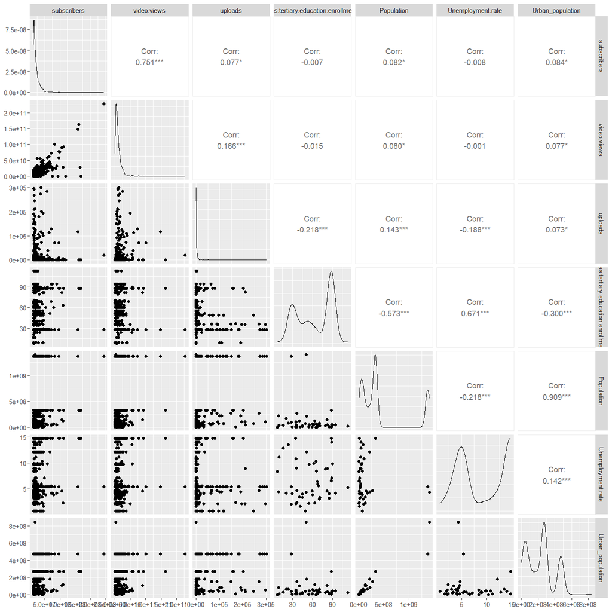

```r
DataCor <- DataClean |>
  select_if(is.numeric) |>
  select(-c(rank, Longitude, Latitude, channel_type_rank, country_rank,
            video_views_rank, video_views_for_the_last_30_days,
            lowest_monthly_earnings, lowest_yearly_earnings, subscribers_for_last_30_days,
            highest_monthly_earnings, highest_yearly_earnings))
ggpairs(DataCor)
```

After conducting the correlation analysis on the dataset, we have identified several significant correlations between variables. These correlations provide valuable insights into the relationships within the dataset and shed light on important trends and patterns. Here are the key findings:

**Subscribers and Video Views**: We observed a strong positive correlation between the number of subscribers and video views on YouTube (r = 0.751, p < 0.001). This indicates that channels with a higher number of subscribers tend to have more video views. It suggests that subscriber count plays a crucial role in driving video views and overall channel engagement.

**Unemployment Rate and Gross Tertiary Education Enrollment (%)**: In the country/region indicators, we found a significant positive correlation between the unemployment rate and gross tertiary education enrollment (r = 0.671, p < 0.001). This suggests that countries/regions with higher unemployment rates tend to have higher enrollment rates in tertiary education. It implies that there might be a relationship between the labor market and the pursuit of higher education.

**Urban Population and Total Population**: Another notable finding is the strong positive correlation between urban population and total population (r = 0.909, p < 0.001). This indicates that as the urban population increases, the total population also tends to increase. It reflects the ongoing trend of urbanization and population growth in various regions.

### Correlation Analysis Between Subscribers and Video Views in Different Country/Region

```r
DataCountry <- DataClean |>
  group_by(Country) |>
  count() |>
  drop_na() |>
  arrange(desc(n)) |>
  head(9)
```

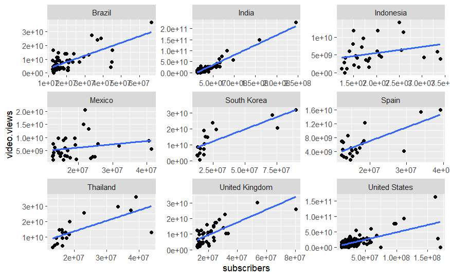

```r
DataClean |>
  filter(Country %in% DataCountry$Country) |>
  ggplot(aes(x = subscribers,
                 y = video.views))+
  geom_point()+
  geom_smooth(method = "lm", se = FALSE)+
  facet_wrap(.~Country, scales = "free")
```

In the dataset, the observations are derived from 49 countries (excluding missing values). Among these countries, the top 9 countries, ranked by their presence in the dataset, are as follows: “United States,” “India,” “Brazil,” “United Kingdom,” “Mexico,” “Indonesia,” “Spain,” “Thailand,” and “South Korea.”

One intriguing observation from the analysis of the dataset is the presence of prominent YouTube channels, often referred to as “top YouTubers,” in each country. These channels have amassed a significant number of video views and subscribers, making them influential figures within the YouTube community.

```r
DataClean |>
  filter(country_rank == 1) |>
  arrange(desc(subscribers)) |>
  select(Youtuber, subscribers, video.views, category, Country, channel_type, date) |>
  datatable(width = "100%", options = list(scrollX = TRUE))
```

|  | Youtuber | subscribers | video.views | category | Country | channel_type | date |
| --- | --- | --- | --- | --- | --- | --- | --- |
| 1 | TSeries | 245000000 | 228000000000 | Music | India | Music | 2006-03-13 |
| 2 | MrBeast | 166000000 | 28368841870 | Entertainment | United States | Entertainment | 2012-02-20 |
| 3 | PewDiePie | 111000000 | 29058044447 | Gaming | Japan | Entertainment | 2010-04-29 |
| 4 | BLACKPINK | 89800000 | 32144597566 | People &amp; Blogs | South Korea | Music | 2016-06-29 |
| 5 | JustinBieber | 71600000 | 30608119724 | Music | Canada | Music | 2007-01-15 |
| 6 | CanalKondZilla | 66500000 | 36775585925 | Music | Brazil | Music | 2012-03-21 |
| 7 | ElReinoInfantil | 58400000 | 57271630846 | Music | Argentina | Music | 2011-06-02 |
| 8 | EdSheeran | 53500000 | 30367676736 | Music | United Kingdom | Music | 2006-08-08 |
| 9 | JuegaGerman | 48100000 | 14631710289 | Gaming | Chile | Games | 2013-05-19 |
| 10 | GetMovies | 47500000 | 30788679536 | Entertainment | Russia | Film | 2006-12-16 |

[output cut: 33 more lines]

Among the top YouTube channels across all countries, an intriguing finding emerges: T-Series, a prominent Indian channel registered in 2006, stands out as the leader in terms of both subscribers and video views. T-Series has achieved remarkable success, surpassing its competitors by a significant margin.

One interesting question that arises from the analysis is whether channels with longer registration times are more likely to accumulate a higher number of subscribers. In the case of T-Series, a prominent Indian channel registered in 2006, it has achieved remarkable success, surpassing its competitors by a significant margin. This raises the question of whether the longevity of a channel’s registration plays a role in attracting more subscribers.

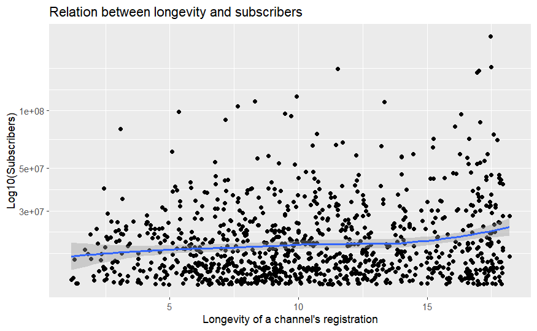

```r
DataClean |>
  mutate(duration = (Sys.Date()-date)/365) |>
  ggplot(aes(x = duration, y = subscribers)) +
  geom_point()+
  geom_smooth()+
  scale_y_continuous(trans = "log10")+
  labs(title = "Relation between longevity and subscribers",
       x = "Longevity of a channel's registration", y = "Log10(Subscribers)", fill = NULL)
```

Upon analyzing the dataset, a noticeable trend emerges regarding the relationship between the longevity of a channel’s registration and the number of subscribers. It appears that as the channel’s registration age increases, there is a slight upward trend in the logarithmically transformed subscriber count.It is important to note that while there is a weak upward trend in the logarithmically transformed subscriber count, other factors may also contribute significantly to a channel’s success. Content quality, engagement with the audience, and effective marketing strategies are among the key elements that can influence a channel’s subscriber count, regardless of its registration age.

## Describing Analysis

### Distribution of Subscribers, Video Views and Uploads

As evident from the provided charts, it is apparent that subscribers, video views, and uploads exhibit significant skewness in their distributions. To accurately model these variables, I will attempt to fit them to log-normal distributions. The log-normal distribution is a probability distribution characterized by its property of transforming skewed data into a form that closely resembles a normal distribution after a logarithmic transformation. By applying a logarithmic transformation to the data, we can approximate the skewed distributions to better align with a normal distribution, enabling a more precise description of the data’s distributional characteristics.

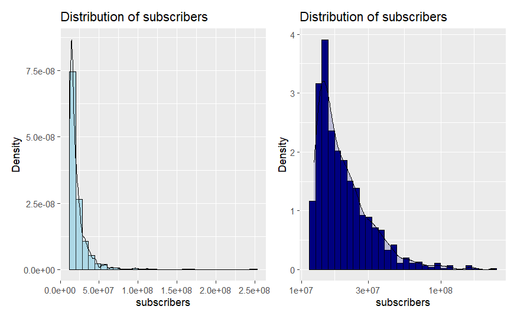

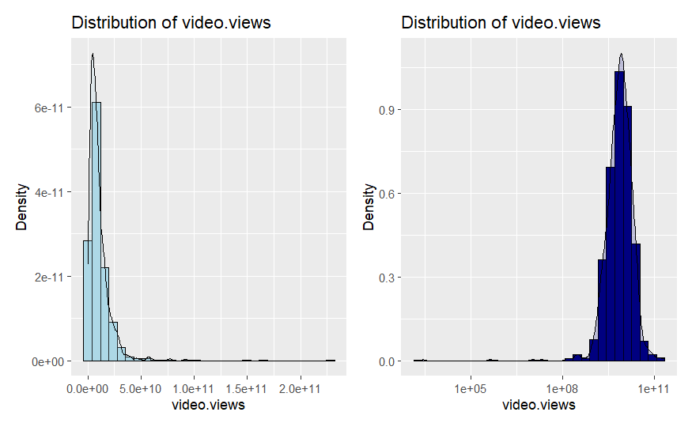

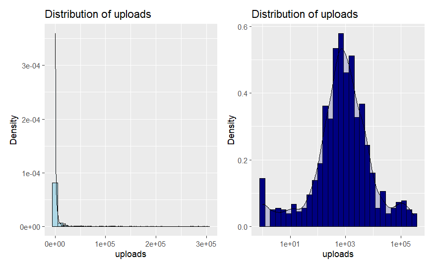

```r
NameList <- c("subscribers", "video.views", "uploads")
name <- NameList[1]
for (name in NameList) {
  ## plot histogram and density
  fig1 <- ggplot(data = data.frame(Col = DataClean[,name]),
         mapping = aes(x = Col))+
    geom_histogram(aes(y = ..density..), bins = 30, fill = "lightblue", color = "black")+
    geom_density(alpha = 0.2, fill = "lightblue")+
    labs(title = paste("Distribution of", name), x = name, y = "Density")
  ## plot log histogram and density
  fig2 <- ggplot(data = data.frame(Col = DataClean[,name]),
         mapping = aes(x = Col))+
    geom_histogram(aes(y = ..density..), bins = 30, fill = "navy", color = "black")+
    geom_density(alpha = 0.2, fill = "navy")+
    scale_x_log10()+
    labs(title = paste("Distribution of", name), x = name, y = "Density")
  print(fig1 + fig2)
}
```

After applying a logarithmic transformation to the variables of video views and uploads, we can observe that they approximate a normal distribution, indicating a relatively symmetrical pattern in their data distributions. However, in the case of subscribers, even after the logarithmic transformation, the distribution continues to exhibit skewness. This suggests that the distribution of subscribers may follow a different pattern, such as a skewed distribution or a mixture of multiple distributions. It is important to consider this characteristic when analyzing and drawing conclusions related to subscribers.

### Distribution inner Different Categories

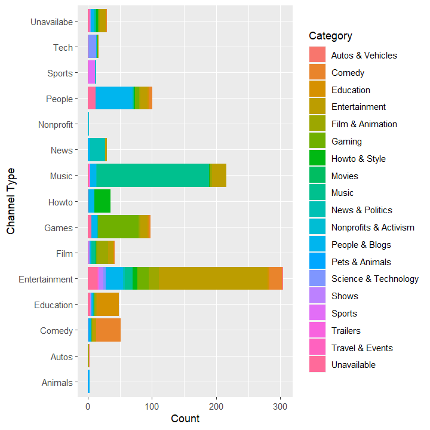

```r
DataClean |>
  ggplot()+
  geom_bar(mapping = aes(y = channel_type, fill = category))+
  labs(fill = "Category",
       y = "Channel Type",
       x = "Count")
```

The most prevalent channel type is Entertainment, followed by Music and People & Blogs. Which suggests that users on YouTube are primarily seeking entertainment content, such as movies, TV shows, and comedic videos. Music-related content, including music videos, performances, and covers, also holds a substantial presence on the platform. People & Blogs channels, which encompass vlogs, personal narratives, and lifestyle content, are also highly popular among YouTube viewers. Within each channel type, the most common categories align with the respective type.

### Distribution across Different Categories

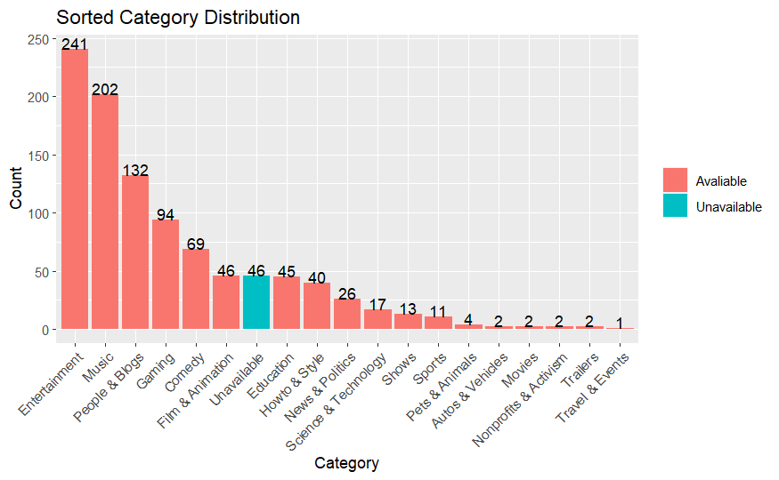

```r
DataClean |>
  count(category) |>
  mutate(ava = if_else(category == "Unavailable",
                       "Unavailable",
                       "Avaliable")) |>
  ggplot(aes(x = reorder(category, -n),
             y = n,
             fill = ava)) +
  geom_bar(stat = "identity") +
  geom_text(aes(label = n), vjust = 0)+
  labs(title = "Sorted Category Distribution", x = "Category", y = "Count", fill = NULL) +
  theme(axis.text.x = element_text(angle = 45, hjust = 1))
```

We can observe that the top few categories with the highest frequency of occurrence in the dataset are “Entertainment”, “Music”, and “People&Blogs”.

### Income Distribution within Categories

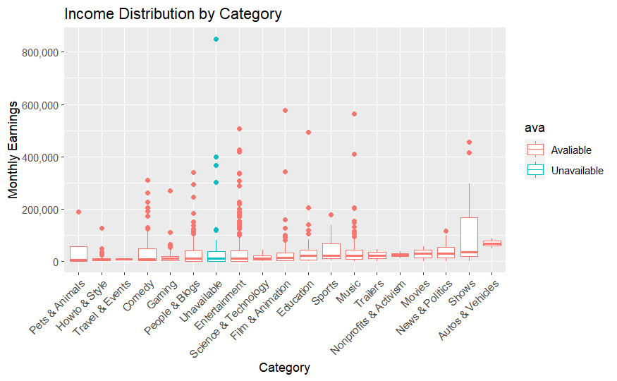

```r
DataClean  |>
  mutate(ava = if_else(category == "Unavailable",
                       "Unavailable",
                       "Avaliable"),
         category = reorder(category, lowest_monthly_earnings, median)) |>
  ggplot(aes(y = lowest_monthly_earnings, x = category, color = ava)) +
  geom_boxplot() +
  scale_y_continuous(labels = scales::comma) +
  labs(title = "Income Distribution by Category", x = "Category", y = "Monthly Earnings") +
  theme(axis.text.x = element_text(angle = 45, hjust = 1))
```

This box chart shows the monthly income distribution of different categories of YouTubers. The X-axis represents categories, while the Y-axis represents monthly income. The box chart shows the median, upper and lower quartiles, and possible outliers of the income distribution for each category. From the chart, it can be seen that there are differences in the income range and distribution of different categories of YouTubers, and some categories may have higher average income.

### Global Distribution of YouTubers

```r
## using leaflet plot map
DataClean |>
  group_by(Country, Longitude, Latitude) |>
  count() |>
  mutate(n = log(n)*5) |>
  leaflet()  |>
  addTiles() |>
  addCircleMarkers(~Longitude, ~Latitude, popup = ~Country, radius = ~n, stroke = F)
```

[interactive chart not shown]

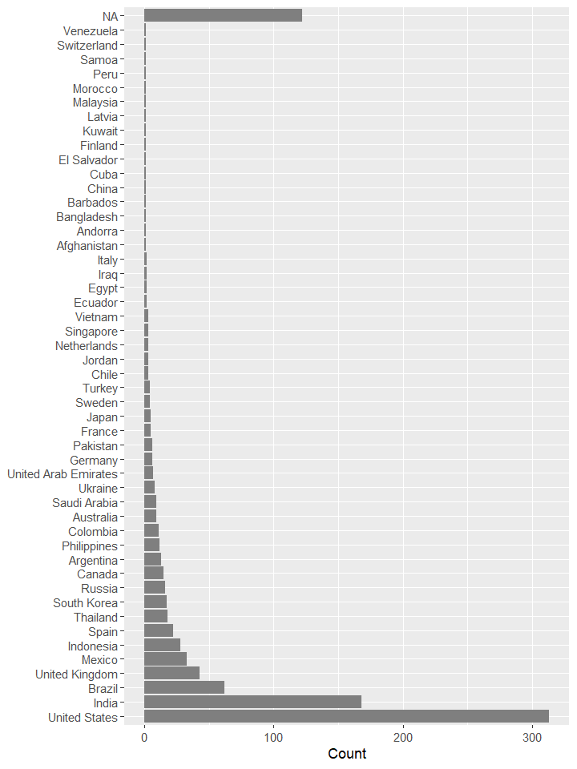

```r
DataClean |>
  group_by(Country) |>
  count() |>
  ggplot() +
  geom_col(mapping = aes(x = reorder(Country, -n),
                         y = n),
           fill = 'grey50')+
  scale_fill_viridis_d()+
  coord_flip()+
  labs(y = 'Count',
       x = NULL)
```

Upon the global map, a clear observation emerges regarding the global distribution of major YouTube channels. The majority of these channels are concentrated in countries such as the United States and India.

# Interactive Analytic Panel

> In the event of a failed webpage loading, you may click on [the link](https://jenniferxie.shinyapps.io/CITS/) to directly navigate to [shinyapps.io](https://www.shinyapps.io/).

> This intercative builded by [shiny](https://shiny.posit.co/) and esquisse packages, and hosted on [shinyapps.io](https://www.shinyapps.io/).

# Statement

[OpenAI ChatGPT-3.5-turbo](https://chat.openai.com/) Used for Chinese translation to English and language polishing.